# Phase 5 — hierarchical ex-ante GPU power

## tl;dr

L0 observed best total MAE 283.5 W on 565 runs (CatBoost, T-total); L1 observed best total MAE 202.7 W on 565 runs (XGBoost, G-perGPU); L2 observed best total MAE 163.0 W on 448 runs (HistGradientBoosting, G-perGPU). These own-support minima are not matched-support feature gains. All 224 cells are complete. Best-of-level has winner selection bias; historical Phase4 confirmatory is not reused as blind evaluation.

## Context & Methods

GPU-side stable high-load text LLM inference only. L0/L0A/L1 preserve565 runs; higher support is based on semantic availability. Eight frozen candidates per nonbaseline learner, five model-group outer folds and three inner folds. Both target strategies select hyperparameters on reconstructed total watts.

### Key Assumptions

Hardware profiles are H100/B200 reference proxies. Missing is distinct from structural N/A. Physics excludes unsupported MLA/hybrid and unknown KV dtype. Adjacent effects use matched supports.

```python
from pathlib import Path
import json
import pandas as pd
import matplotlib.pyplot as plt
from IPython.display import Image,display
ROOT=next((p for p in [Path.cwd(),*Path.cwd().parents] if (p/'step7/config/protocol_freeze.json').exists()),None)
if ROOT is None:
 raise FileNotFoundError('Open inside the delivered repository with the step7 evidence files present')
STEP7=ROOT/'step7'
REPORTS=STEP7/'reports'
coverage=pd.read_csv(STEP7/'analysis/cohort_coverage.csv')
matrix=pd.read_csv(REPORTS/'main_model_matrix.csv')
increments=pd.read_csv(REPORTS/'feature_increment_effects.csv')
targets=pd.read_csv(REPORTS/'target_representation_comparison.csv')
slices=pd.read_csv(REPORTS/'slice_metrics.csv')
lock=json.loads((STEP7/'config/development_candidates_lock.json').read_text())
assert matrix.experiment_id.nunique()==224
plt.rcParams.update({'figure.figsize':(10,5),'axes.grid':True,'grid.alpha':.4,'axes.prop_cycle':plt.cycler(color=['#176B87','#B06B18'])})
```

## Data

```python
display(coverage[['feature_level','n_rows','n_models','n_lineages','n_architectures']])
display(pd.read_csv(STEP7/'analysis/tokenizer_free_text_audit.csv'))
```

|  | feature_level | n_rows | n_models | n_lineages | n_architectures |
| --- | --- | --- | --- | --- | --- |
| 0 | L0-Basic | 565 | 27 | 6 | 3 |
| 1 | L0A-ActiveAware | 565 | 27 | 6 | 3 |
| 2 | L1-Deployment | 565 | 27 | 6 | 3 |
| 3 | L2-StaticCore | 448 | 20 | 5 | 3 |
| 4 | L3-Workload | 448 | 20 | 5 | 3 |
| 5 | L4-CompactPhysics | 305 | 14 | 2 | 2 |
| 6 | L3E-Effective | 383 | 18 | 4 | 3 |
| 7 | L2X-StaticExtended | 448 | 20 | 5 | 3 |
| 8 | L4B5-OldB5Sensitivity | 305 | 14 | 2 | 2 |
| 9 | L1-TaskSensitivity | 565 | 27 | 6 | 3 |
| 10 | L1T-TokenizerFreeTextProxy | 565 | 27 | 6 | 3 |

|  | task | status | reason | n_requests | request_list_sha256 |
| --- | --- | --- | --- | --- | --- |
| 0 | gpqa | verified | exact frozen request-list hash; no tokenizer o... | 198 | 7a647ecfc9dad4434227d20acb5137af91c9f3ee32552a... |
| 1 | lm-arena-chat | verified | exact frozen request-list hash; no tokenizer o... | 1024 | 2f801cd5bf61f0b709f74915fda9cf102be5693246304e... |
| 2 | sourcegraph-fim | verified | exact frozen request-list hash; no tokenizer o... | 1024 | 1799ba0b7d47e52dfe55aea544dbab9b82e5f4f1cf37b6... |

## Results

### Information and observed accuracy

Supports above L1 differ; use paired increments rather than this curve for feature-value claims.

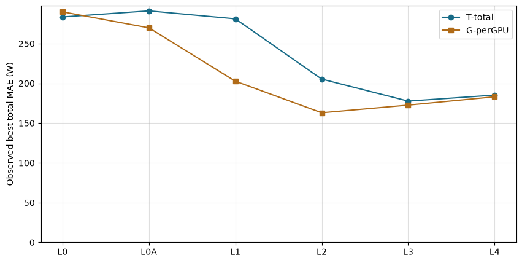

|  | feature_level | target_strategy | algorithm | n_rows | mae | per_gpu_mae |
| --- | --- | --- | --- | --- | --- | --- |
| 0 | L2-StaticCore | G-perGPU | HistGradientBoosting | 448 | 162.991 | 82.193 |
| 1 | L3-Workload | G-perGPU | XGBoost | 448 | 172.646 | 72.776 |
| 2 | L3-Workload | T-total | XGBoost | 448 | 177.683 | 68.175 |
| 3 | L4-CompactPhysics | G-perGPU | XGBoost | 305 | 183.111 | 67.307 |
| 4 | L4-CompactPhysics | T-total | XGBoost | 305 | 185.233 | 62.478 |
| 5 | L1-Deployment | G-perGPU | XGBoost | 565 | 202.698 | 82.501 |
| 6 | L2-StaticCore | T-total | HistGradientBoosting | 448 | 205.311 | 88.021 |
| 7 | L0A-ActiveAware | G-perGPU | CatBoost | 565 | 269.846 | 98.344 |
| 8 | L1-Deployment | T-total | XGBoost | 565 | 281.165 | 112.634 |
| 9 | L0-Basic | T-total | CatBoost | 565 | 283.519 | 98.112 |
| 10 | L0-Basic | G-perGPU | HistGradientBoosting | 565 | 289.978 | 98.278 |
| 11 | L0A-ActiveAware | T-total | RandomForest | 565 | 291.174 | 101.845 |

```python
curve=pd.read_csv(REPORTS/'information_curve_source.csv')
levels=['L0-Basic','L0A-ActiveAware','L1-Deployment','L2-StaticCore','L3-Workload','L4-CompactPhysics']
fig,ax=plt.subplots()
for strategy,marker in [('T-total','o'),('G-perGPU','s')]:
 data=curve.loc[curve.target_strategy.eq(strategy)].set_index('feature_level').reindex(levels)
 ax.plot(range(6),data.mae,marker=marker,label=strategy)
ax.set_xticks(range(6),[x.split('-')[0] for x in levels])
ax.set_ylabel('Observed best total MAE (W)')
ax.set_ylim(bottom=0)
ax.legend()
plt.show()
display(curve[['feature_level','target_strategy','algorithm','n_rows','mae','per_gpu_mae']].round(3))
```

### Matched-support feature and target effects

|  | lower | higher | algorithm | target_strategy | n_rows | row_weighted_delta_mae | row_ci_low | row_ci_high |
| --- | --- | --- | --- | --- | --- | --- | --- | --- |
| 0 | L0-Basic | L0A-ActiveAware | DummyMean | T-total | 565 | 0.000 | 0.000 | 0.000 |
| 1 | L0-Basic | L0A-ActiveAware | DummyMean | G-perGPU | 565 | 0.000 | 0.000 | 0.000 |
| 2 | L0-Basic | L0A-ActiveAware | Ridge | T-total | 565 | -3.355 | -67.263 | 84.087 |
| 3 | L0-Basic | L0A-ActiveAware | Ridge | G-perGPU | 565 | -8.051 | -84.642 | 59.364 |
| 4 | L0-Basic | L0A-ActiveAware | ElasticNet | T-total | 565 | 4.326 | -55.038 | 84.641 |
| 5 | L0-Basic | L0A-ActiveAware | ElasticNet | G-perGPU | 565 | -5.449 | -71.226 | 54.778 |
| 6 | L0-Basic | L0A-ActiveAware | HistGradientBoosting | T-total | 565 | -18.417 | -45.656 | 4.630 |
| 7 | L0-Basic | L0A-ActiveAware | HistGradientBoosting | G-perGPU | 565 | 11.549 | -26.899 | 57.154 |
| 8 | L0-Basic | L0A-ActiveAware | RandomForest | T-total | 565 | 4.253 | -15.289 | 29.315 |
| 9 | L0-Basic | L0A-ActiveAware | RandomForest | G-perGPU | 565 | -21.922 | -68.049 | 4.300 |
| 10 | L0-Basic | L0A-ActiveAware | ExtraTrees | T-total | 565 | -3.516 | -16.938 | 9.534 |
| 11 | L0-Basic | L0A-ActiveAware | ExtraTrees | G-perGPU | 565 | -7.682 | -22.905 | 1.877 |
| 12 | L0-Basic | L0A-ActiveAware | XGBoost | T-total | 565 | -25.429 | -60.594 | 7.125 |
| 13 | L0-Basic | L0A-ActiveAware | XGBoost | G-perGPU | 565 | -18.217 | -39.536 | -0.203 |
| 14 | L0-Basic | L0A-ActiveAware | CatBoost | T-total | 565 | 11.717 | -24.696 | 55.859 |
| 15 | L0-Basic | L0A-ActiveAware | CatBoost | G-perGPU | 565 | -24.222 | -53.924 | -4.014 |
| 16 | L0A-ActiveAware | L1-Deployment | DummyMean | T-total | 565 | 0.000 | 0.000 | 0.000 |
| 17 | L0A-ActiveAware | L1-Deployment | DummyMean | G-perGPU | 565 | 0.000 | 0.000 | 0.000 |
| 18 | L0A-ActiveAware | L1-Deployment | Ridge | T-total | 565 | -24.830 | -86.147 | 22.578 |
| 19 | L0A-ActiveAware | L1-Deployment | Ridge | G-perGPU | 565 | 33.593 | -52.175 | 186.952 |
| 20 | L0A-ActiveAware | L1-Deployment | ElasticNet | T-total | 565 | -27.847 | -88.024 | 16.858 |
| 21 | L0A-ActiveAware | L1-Deployment | ElasticNet | G-perGPU | 565 | -27.251 | -59.982 | 3.331 |
| 22 | L0A-ActiveAware | L1-Deployment | HistGradientBoosting | T-total | 565 | -44.999 | -93.346 | 1.399 |
| 23 | L0A-ActiveAware | L1-Deployment | HistGradientBoosting | G-perGPU | 565 | -91.243 | -166.776 | -29.111 |

|  | feature_level | algorithm | n_rows | row_weighted_delta_mae | row_ci_low | row_ci_high |
| --- | --- | --- | --- | --- | --- | --- |
| 0 | L0-Basic | DummyMean | 565 | -1055.406 | -1365.906 | -753.039 |
| 1 | L0-Basic | Ridge | 565 | -14.276 | -57.670 | 39.091 |
| 2 | L0-Basic | ElasticNet | 565 | -8.264 | -47.912 | 38.403 |
| 3 | L0-Basic | HistGradientBoosting | 565 | -76.595 | -159.743 | -4.046 |
| 4 | L0-Basic | RandomForest | 565 | 9.306 | -30.646 | 56.120 |
| 5 | L0-Basic | ExtraTrees | 565 | -4.917 | -58.380 | 39.048 |
| 6 | L0-Basic | XGBoost | 565 | -42.303 | -107.575 | 10.148 |
| 7 | L0-Basic | CatBoost | 565 | 10.550 | -15.921 | 38.686 |
| 8 | L0A-ActiveAware | DummyMean | 565 | -1055.406 | -1365.906 | -753.039 |
| 9 | L0A-ActiveAware | Ridge | 565 | -18.973 | -92.733 | 51.613 |
| 10 | L0A-ActiveAware | ElasticNet | 565 | -18.039 | -81.305 | 42.133 |
| 11 | L0A-ActiveAware | HistGradientBoosting | 565 | -46.629 | -120.339 | 16.069 |
| 12 | L0A-ActiveAware | RandomForest | 565 | -16.869 | -63.021 | 13.898 |
| 13 | L0A-ActiveAware | ExtraTrees | 565 | -9.083 | -64.879 | 26.197 |
| 14 | L0A-ActiveAware | XGBoost | 565 | -35.091 | -88.268 | 10.669 |
| 15 | L0A-ActiveAware | CatBoost | 565 | -25.390 | -88.583 | 15.556 |
| 16 | L1-Deployment | DummyMean | 565 | -1055.406 | -1365.906 | -753.039 |
| 17 | L1-Deployment | Ridge | 565 | 39.450 | -40.549 | 176.228 |
| 18 | L1-Deployment | ElasticNet | 565 | -17.443 | -43.843 | 10.253 |
| 19 | L1-Deployment | HistGradientBoosting | 565 | -92.872 | -188.226 | -14.881 |
| 20 | L1-Deployment | RandomForest | 565 | -46.883 | -134.107 | 15.916 |
| 21 | L1-Deployment | ExtraTrees | 565 | -85.091 | -212.115 | -4.518 |
| 22 | L1-Deployment | XGBoost | 565 | -78.467 | -196.904 | 19.399 |
| 23 | L1-Deployment | CatBoost | 565 | -74.531 | -189.982 | 13.303 |

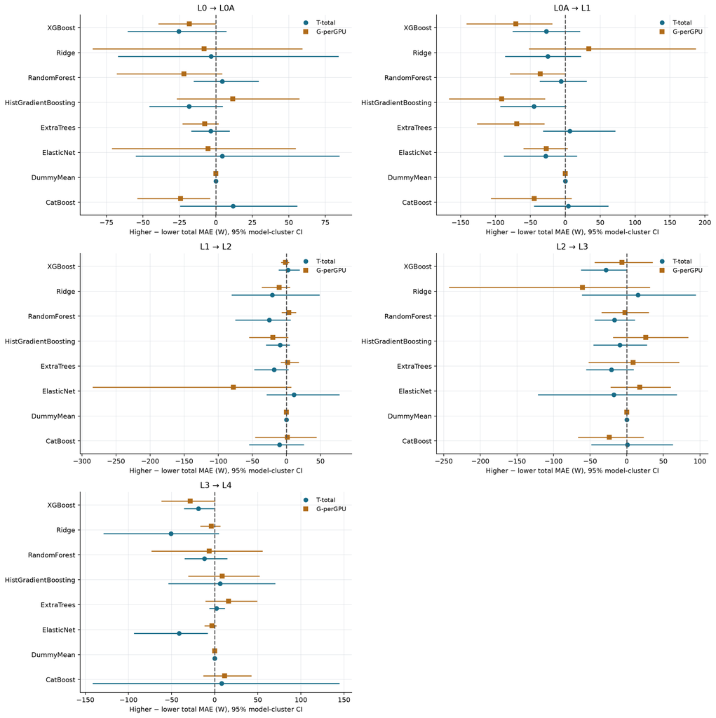

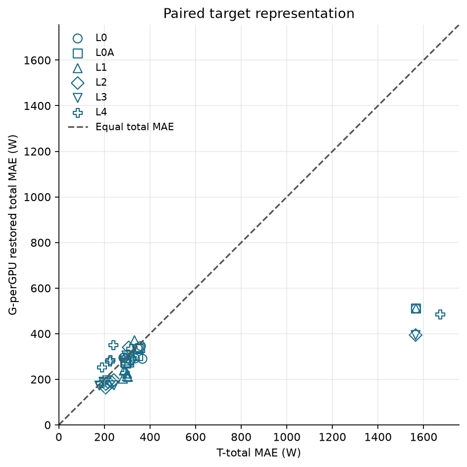

```python
display(increments[['lower','higher','algorithm','target_strategy','n_rows','row_weighted_delta_mae','row_ci_low','row_ci_high']].head(24).round(3))
display(targets[['feature_level','algorithm','n_rows','row_weighted_delta_mae','row_ci_low','row_ci_high']].head(24).round(3))
display(Image(filename=str(STEP7/'figures/feature_increment_forest.png'),width=1100))
display(Image(filename=str(STEP7/'figures/total_per_gpu_paired.png'),width=750))
```

### GPU-count scaling and calibration

Average per-GPU error is aggregate error divided by card count, not a per-card measurement.

|  | target_strategy | slice_value | n_rows | mae | per_gpu_mae | signed_bias |
| --- | --- | --- | --- | --- | --- | --- |
| 0 | T-total | 1 | 250 | 161.261 | 161.261 | 66.513 |
| 1 | T-total | 2 | 104 | 165.357 | 82.678 | 99.751 |
| 2 | T-total | 4 | 83 | 198.171 | 49.543 | 17.025 |
| 3 | T-total | 8 | 128 | 663.265 | 82.908 | -240.963 |
| 4 | G-perGPU | 1 | 250 | 118.413 | 118.413 | 5.892 |
| 5 | G-perGPU | 2 | 104 | 112.041 | 56.021 | -29.002 |
| 6 | G-perGPU | 4 | 83 | 195.198 | 48.800 | 30.138 |
| 7 | G-perGPU | 8 | 128 | 445.838 | 55.730 | 87.536 |

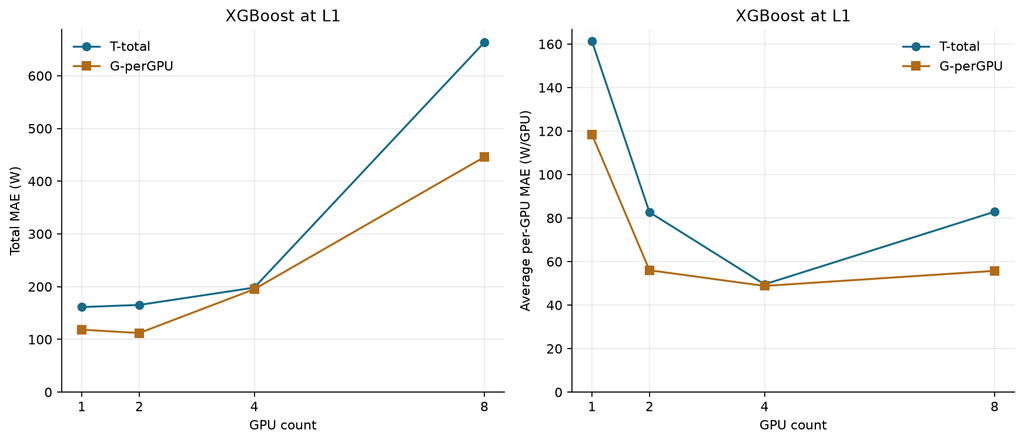

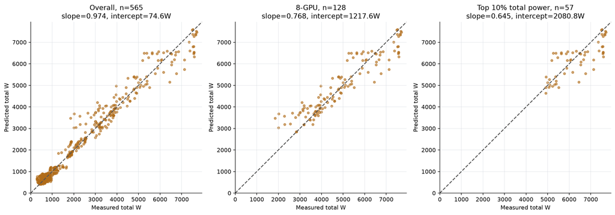

```python
display(pd.read_csv(REPORTS/'gpu_count_scaling_source.csv')[['target_strategy','slice_value','n_rows','mae','per_gpu_mae','signed_bias']].round(3))
display(Image(filename=str(STEP7/'figures/gpu_count_error_scaling.png'),width=1000))
display(Image(filename=str(STEP7/'figures/calibration_overall_8gpu_top10.png'),width=1200))
```

### Development candidates and post-hoc stresses

```python
display(pd.DataFrame(lock['choices'].values())[['feature_level','algorithm','target_strategy','n_rows','mae','per_gpu_mae']].round(3))
stress=pd.read_csv(REPORTS/'generalization_stress.csv')
display(stress[['feature_level','scheme','held_out_group','task','n_rows','mae','per_gpu_mae','signed_bias']].sort_values('mae',ascending=False).head(12).round(3))
```

|  | feature_level | algorithm | target_strategy | n_rows | mae | per_gpu_mae |
| --- | --- | --- | --- | --- | --- | --- |
| 0 | L0-Basic | CatBoost | T-total | 565 | 283.519 | 98.112 |
| 1 | L1-Deployment | XGBoost | G-perGPU | 565 | 202.698 | 82.501 |
| 2 | L2-StaticCore | HistGradientBoosting | G-perGPU | 448 | 162.991 | 82.193 |
| 3 | L3-Workload | XGBoost | G-perGPU | 448 | 172.646 | 72.776 |

|  | feature_level | scheme | held_out_group | task | n_rows | mae | per_gpu_mae | signed_bias |
| --- | --- | --- | --- | --- | --- | --- | --- | --- |
| 0 | L0-Basic | parent_lineage | DeepSeek | NaN | 22 | 2091.583 | 261.448 | 2091.583 |
| 9 | L0-Basic | within_task_lineage | DeepSeek | gpqa | 11 | 1587.677 | 198.460 | -1587.677 |
| 13 | L0-Basic | within_task_lineage | DeepSeek | lm-arena-chat | 11 | 1252.804 | 156.600 | -1227.376 |
| 18 | L1-Deployment | parent_lineage | DeepSeek | NaN | 22 | 1201.481 | 150.185 | 1175.860 |
| 36 | L2-StaticCore | parent_lineage | DeepSeek | NaN | 22 | 1081.028 | 135.129 | 1060.305 |
| 15 | L0-Basic | within_task_lineage | Llama | lm-arena-chat | 117 | 965.200 | 205.230 | -714.419 |
| 44 | L2-StaticCore | within_task_lineage | DeepSeek | gpqa | 11 | 799.191 | 99.899 | 185.632 |
| 3 | L0-Basic | parent_lineage | Llama | NaN | 117 | 713.835 | 153.822 | -301.464 |
| 27 | L1-Deployment | within_task_lineage | DeepSeek | gpqa | 11 | 705.753 | 88.219 | 516.546 |
| 12 | L0-Basic | within_task_lineage | Qwen | gpqa | 83 | 604.289 | 227.963 | 187.866 |
| 8 | L0-Basic | architecture | mixture_of_experts | NaN | 306 | 571.617 | 126.116 | 268.032 |
| 26 | L1-Deployment | architecture | mixture_of_experts | NaN | 306 | 534.556 | 114.093 | 464.417 |

## Takeaways

Use same-support paired estimates for information gains; compare both reconstructed total and average per-GPU errors for target representation. Candidate choices are engineering development fits without external validation. Stress tests are post-hoc and never feed back into feature/algorithm/hyperparameter decisions. The Chinese scientific report answers RQ1–RQ8 and records coverage, search-budget and winner-selection limitations.